# Comparing outputs from XMAS2, lefse-conda, and lefse-galaxy using the same in-house datasets (amplicon_ps|Zeybel_Gut)

Hua Zou

zouhua@xbiome.com

Created: 2022-07-18; Updated: 2022-07-20

# Introduction

In this document, Comparing the output from lefse through different applications:

- XMAS2 (R package)
- lefse-conda (command line)
- lefse-galaxy (from the galaxy platfrom)

In all cases, using the same dataset, amplicon_ps and Zeybel_Gut, which are included in the XMAS package.

# Dataset

## 16s genus

```r
data("amplicon_ps")
amplicon_ps_genus <- summarize_taxa(amplicon_ps, taxa_level = "Genus")
amplicon_ps_genus
```

```
## phyloseq-class experiment-level object
## otu_table()   OTU Table:         [ 406 taxa and 34 samples ]
## sample_data() Sample Data:       [ 34 samples by 8 sample variables ]
## tax_table()   Taxonomy Table:    [ 406 taxa by 6 taxonomic ranks ]
```

## metagenomics species

```r
data("Zeybel_Gut")
Zeybel_ps_species <- summarize_taxa(Zeybel_Gut, taxa_level = "Species")
Zeybel_ps_species
```

```
## phyloseq-class experiment-level object
## otu_table()   OTU Table:         [ 372 taxa and 42 samples ]
## sample_data() Sample Data:       [ 42 samples by 51 sample variables ]
## tax_table()   Taxonomy Table:    [ 372 taxa by 7 taxonomic ranks ]
```

## Preparing for lefse galaxy and conda

```r
prepare_lefse <- function(ps,
                          Class,
                          Class_names,
                          Subclass = NULL,
                          cutoff = 10) {

    # ps = amplicon_ps_genus
    # Class = "SampleType"
    # Class_names = c("gut", "tongue")
    # Subclass = NULL
    # cutoff = 10

    sam_tab <- phyloseq::sample_data(ps) %>%
        data.frame()
    colnames(sam_tab)[which(colnames(sam_tab) == Class)] <- "CompClass"

    if (is.null(Subclass)) {
        sam_tab_final <- sam_tab %>%
            dplyr::select(CompClass) %>%
            tibble::rownames_to_column("TempRowNames") %>%
            dplyr::filter(CompClass %in% Class_names) %>%
            dplyr::select(all_of(c("TempRowNames", "CompClass"))) %>%
            tibble::column_to_rownames("TempRowNames")
    } else {
        sam_tab_final <- sam_tab %>%
            dplyr::select(all_of(c("CompClass", Subclass))) %>%
            tibble::rownames_to_column("TempRowNames") %>%
            dplyr::filter(CompClass %in% Class_names) %>%
            dplyr::select(all_of(c("TempRowNames", "CompClass", Subclass))) %>%
            tibble::column_to_rownames("TempRowNames")
    }

    colnames(sam_tab_final)[which(colnames(sam_tab_final) == "CompClass")] <- Class

    phyloseq::sample_data(ps) <- phyloseq::sample_data(sam_tab_final)
    otu_tab <- phyloseq::otu_table(ps) %>%
        data.frame()
    otu_tab_final <- otu_tab[rowSums(otu_tab) > cutoff, colSums(otu_tab) > cutoff, F]
    phyloseq::otu_table(ps) <- phyloseq::otu_table(as.matrix(otu_tab_final), taxa_are_rows = TRUE)

    lefse_data <- sam_tab_final %>%
        tibble::rownames_to_column("Sample") %>%
        dplyr::inner_join(otu_tab_final %>%
                              t() %>% data.frame() %>%
                              tibble::rownames_to_column("Sample"),
                          by = "Sample") %>%
        dplyr::select(all_of(Class), Sample, all_of(Subclass), everything()) %>%
        #stats::setNames(c(Class, "Sample", Subclass, rownames(otu_tab_final))) %>%
        t() %>% data.frame()

    lefse_data_nosub <- sam_tab_final %>%
        tibble::rownames_to_column("Sample") %>%
        dplyr::inner_join(otu_tab_final %>%
                              t() %>% data.frame() %>%
                              tibble::rownames_to_column("Sample"),
                          by = "Sample") %>%
        dplyr::select(-Sample) %>%
        dplyr::select(all_of(Class), all_of(Subclass), everything()) %>%
        t() %>% data.frame()

    res <- list(ps=ps,
                lefse=lefse_data,
                lefse_nosub=lefse_data_nosub)

    return(res)
}

amplicon_ps_genus_lefse <- prepare_lefse(
                          ps = amplicon_ps_genus,
                          Class = "SampleType",
                          Class_names = c("gut", "tongue"),
                          cutoff = 10)

write.table(amplicon_ps_genus_lefse$lefse, "amplicon_ps_genus_lefse.tsv", quote = F, sep = "\t", col.names = F)
write.table(amplicon_ps_genus_lefse$lefse_nosub, "amplicon_ps_genus_lefse_nosub.tsv", quote = F, sep = "\t", col.names = F)

Zeybel_ps_species_lefse <- prepare_lefse(
                          ps = Zeybel_ps_species,
                          Class = "LiverFatClass",
                          Class_names = c("Mild", "Moderate"),
                          cutoff = 1e-4)

write.table(Zeybel_ps_species_lefse$lefse, "Zeybel_ps_species_lefse.tsv", quote = F, sep = "\t", col.names = F)
write.table(Zeybel_ps_species_lefse$lefse_nosub, "Zeybel_ps_species_lefse_nosub.tsv", quote = F, sep = "\t", col.names = F)
```

# Run lefse independently with the three applications (R, conda, galaxy)

## Running lefse in R (XMAS2)

Perform the analysis with the `run_lefse2` function:

- amplicon_ps_genus

```r
# run_lefse
amplicon_xmas2_output <- run_lefse(
                          ps = amplicon_ps_genus_lefse$ps,
                          group = "SampleType",
                          group_names = c("gut", "tongue"),
                          norm = "CPM") %>%
    dplyr::mutate(app_name = "xmas_lefse") %>%
    dplyr::arrange(LDA_Score)
head(amplicon_xmas2_output)
```

```
##                            TaxaID             Block Enrichment LDA_Score
## 1                  g__Bacteroides 8_gut vs 9_tongue        gut -5.464661
## 2 g__Lachnospiraceae_unclassified 8_gut vs 9_tongue        gut -4.451749
## 3                  g__Lachnospira 8_gut vs 9_tongue        gut -4.404415
## 4 g__Ruminococcaceae_unclassified 8_gut vs 9_tongue        gut -4.394309
## 5             g__Faecalibacterium 8_gut vs 9_tongue        gut -4.206251
## 6        g__Phascolarctobacterium 8_gut vs 9_tongue        gut -4.183912
##   EffectSize Log2FoldChange (Median)\ngut_vs_tongue Median Abundance\n(All)
## 1   5.734982                               8.706188               4552.3520
## 2   2.296951                               3.048798              11431.9387
## 3   6.503718                                     NA                  0.0000
## 4   5.962548                               8.833464                945.6265
## 5   5.492180                                     NA                  0.0000
## 6   6.206589                                     NA                  0.0000
##   Median Abundance\ngut Median Abundance\ntongue
```

[output cut: 34 more lines]

```r
# run_lefse2
amplicon_xmas2_output2 <- run_lefse2(
                          ps = amplicon_ps_genus_lefse$ps,
                          group = "SampleType",
                          group_names = c("gut", "tongue"),
                          norm = "CPM") %>%
    dplyr::mutate(app_name = "xmas_lefse2") %>%
    dplyr::arrange(LDA_Score)
head(amplicon_xmas2_output2)
```

```
##                            TaxaID             Block LDA_Score Enrichment
## 1                  g__Bacteroides 8_gut vs 9_tongue -5.765206        gut
## 2 g__Lachnospiraceae_unclassified 8_gut vs 9_tongue -4.772429        gut
## 3 g__Ruminococcaceae_unclassified 8_gut vs 9_tongue -4.741137        gut
## 4                  g__Lachnospira 8_gut vs 9_tongue -4.685915        gut
## 5             g__Faecalibacterium 8_gut vs 9_tongue -4.481811        gut
## 6        g__Phascolarctobacterium 8_gut vs 9_tongue -4.468520        gut
##   EffectSize       Pvalue Log2FoldChange (Median)\ngut_vs_tongue
## 1   5.734982 0.0005320055                               8.706188
## 2   2.296951 0.0005320055                               3.048798
## 3   5.962548 0.0004911726                               8.833464
## 4   6.503718 0.0001762277                                     NA
## 5   5.492180 0.0001762277                                     NA
## 6   6.206589 0.0001762277                                     NA
##   Median Abundance\n(All) Median Abundance\ngut Median Abundance\ntongue
```

[output cut: 34 more lines]

- Zeybel_ps_species

```r
# run_lefse
MGS_xmas2_output <- run_lefse(
                          ps = Zeybel_ps_species_lefse$ps,
                          group = "LiverFatClass",
                          group_names = c("Mild", "Moderate"),
                          norm = "CPM") %>%
    dplyr::mutate(app_name = "xmas_lefse") %>%
    dplyr::arrange(LDA_Score)
head(MGS_xmas2_output)
```

```
##                            TaxaID                  Block Enrichment LDA_Score
## 1         s__Butyricimonas_virosa 12_Mild vs 12_Moderate   Moderate  2.462833
## 2       s__Bacteroides_salyersiae 12_Mild vs 12_Moderate   Moderate  2.628574
## 3 s__Bacteroides_thetaiotaomicron 12_Mild vs 12_Moderate   Moderate  3.177126
## 4           s__Bacteroides_clarus 12_Mild vs 12_Moderate   Moderate  3.221333
## 5        s__Bacteroides_coprocola 12_Mild vs 12_Moderate   Moderate  3.310338
## 6 s__Bacteroides_cellulosilyticus 12_Mild vs 12_Moderate   Moderate  3.332193
##   EffectSize Log2FoldChange (Median)\nMild_vs_Moderate Median Abundance\n(All)
## 1   1.668501                                        NA               0.8999998
## 2   1.573816                                        NA               0.0000000
## 3   2.775490                                        NA             223.8648101
## 4   2.331714                                        NA               0.0000000
## 5   1.367262                                        NA               0.0000000
## 6   3.145457                                        NA              82.9748375
##   Median Abundance\nMild Median Abundance\nModerate
```

[output cut: 34 more lines]

```r
# run_lefse2
MGS_xmas2_output2 <- run_lefse2(
                          ps = Zeybel_ps_species_lefse$ps,
                          group = "LiverFatClass",
                          group_names = c("Mild", "Moderate"),
                          norm = "CPM") %>%
    dplyr::mutate(app_name = "xmas_lefse2") %>%
    dplyr::arrange(LDA_Score)
head(MGS_xmas2_output2)
```

```
##                            TaxaID                  Block LDA_Score Enrichment
## 1         s__Butyricimonas_virosa 12_Mild vs 12_Moderate  2.735285   Moderate
## 2       s__Bacteroides_salyersiae 12_Mild vs 12_Moderate  2.776971   Moderate
## 3 s__Bacteroides_thetaiotaomicron 12_Mild vs 12_Moderate  3.437617   Moderate
## 4     s__Bacteroides_intestinalis 12_Mild vs 12_Moderate  3.449263   Moderate
## 5        s__Bacteroides_coprocola 12_Mild vs 12_Moderate  3.457030   Moderate
## 6           s__Bacteroides_clarus 12_Mild vs 12_Moderate  3.474700   Moderate
##   EffectSize     Pvalue Log2FoldChange (Median)\nMild_vs_Moderate
## 1   1.668501 0.02432292                                        NA
## 2   1.573816 0.03286923                                        NA
## 3   2.775490 0.01050852                                        NA
## 4   1.184353 0.03286923                                        NA
## 5   1.367262 0.03286923                                        NA
## 6   2.331714 0.01473169                                        NA
##   Median Abundance\n(All) Median Abundance\nMild Median Abundance\nModerate
```

[output cut: 34 more lines]

## Running lefse-conda (command line)

### lefse-conda installation and version

Note: I installed lefse following the instructions from [this site](https://github.com/biobakery/conda-biobakery) after installing conda.

```bash
## Add channels
conda config --add channels defaults
conda config --add channels bioconda
conda config --add channels conda-forge
conda config --add channels biobakery

## Install lefse
conda create -n lefse -c biobakery lefse -y
```

Conda and lefse versions:

```bash
conda --version
#> conda 4.12.0

conda list | grep -e "lefse"
# packages in environment at /home/samuel/miniconda3/envs/lefse:
#> lefse                     1.1.2              pyhdfd78af_0    bioconda
```

### Run lefse-conda

1. Generate a tabular dataset (amplicon_ps_genus_lefse or Zeybel_ps_species_lefse) compatible with lefse-conda and lefse-galaxy using the `get_dataset.R` script.
2. Run the script `run_lefse.sh` (linux) with the following parameters:

```bash
# In general
# ./run_lefse.sh <path/to/conda/activate> <env_name> <path/to/Rscript> <filename prefix>

# in my case (Hua Zou)

## amplicon_ps_genus_lefse
./run_lefse.sh /Users/zouhua/opt/anaconda3/bin/activate lefse /usr/local/bin/R amplicon_ps_genus_lefse

## Zeybel_ps_species_lefse
./run_lefse.sh /Users/zouhua/opt/anaconda3/bin/activate lefse /usr/local/bin/R Zeybel_ps_species_lefse
```

Note: All script files, `get_dataset.R` and `run_lefse.sh`, and this rmarkdown document must be in the same directory.

### Import output from lefse-conda into R

```r
get_lefse_python <- function(datres,
                            Class_names,
                            name = "lefse_conda",
                            LDA_names = "lefse_conda_LDA",
                            LDA_cutoff = 2) {

    # datres = "amplicon_ps_genus_lefse.res"
    # Class_names = c("gut", "tongue")
    # LDA_cutoff = 2

    col_names <- c(
        "TaxaID", "log_hi_class_avg", "Enrichment", "lefse_conda_LDA", "pval")
    lefse_conda <- readr::read_tsv(datres, show_col_types = FALSE, col_names = FALSE ) %>%
        magrittr::set_colnames(col_names) %>%
        dplyr::filter(!is.na(lefse_conda_LDA)) %>%
        dplyr::mutate(
            lefse_conda_LDA = ifelse(
                Enrichment == Class_names[1], -lefse_conda_LDA, lefse_conda_LDA),
            app_name = name) %>%
        dplyr::filter(abs(lefse_conda_LDA) >= LDA_cutoff) %>%
        dplyr::arrange(lefse_conda_LDA)

    colnames(lefse_conda)[which(colnames(lefse_conda) == "lefse_conda_LDA")] <- LDA_names

    return(lefse_conda)
}

amplicon_ps_genus_lefse_conda <- get_lefse_python(
                    datres = "amplicon_ps_genus_lefse.res",
                    Class_names = c("gut", "tongue"),
                    LDA_names = "lefse_conda_LDA")
head(amplicon_ps_genus_lefse_conda)
```

```
## # A tibble: 6 × 6
##   TaxaID              log_hi_class_avg Enrichment lefse_conda_LDA pval  app_name
##   <chr>                          <dbl> <chr>                <dbl> <chr> <chr>
## 1 g__Bacteroides                  5.77 gut                  -5.47 0.00… lefse_c…
## 2 g__Lachnospiraceae…             4.82 gut                  -4.47 0.00… lefse_c…
## 3 g__Ruminococcaceae…             4.75 gut                  -4.46 0.00… lefse_c…
## 4 g__Lachnospira                  4.68 gut                  -4.36 0.00… lefse_c…
## 5 g__Faecalibacterium             4.47 gut                  -4.20 0.00… lefse_c…
## 6 g__Phascolarctobac…             4.46 gut                  -4.15 0.00… lefse_c…
```

```r
Zeybel_ps_species_lefse_conda <- get_lefse_python(
                    datres = "Zeybel_ps_species_lefse.res",
                    Class_names = c("Mild", "Moderate"),
                    LDA_names = "lefse_conda_LDA")
head(Zeybel_ps_species_lefse_conda)
```

```
## # A tibble: 6 × 6
##   TaxaID              log_hi_class_avg Enrichment lefse_conda_LDA pval  app_name
##   <chr>                          <dbl> <chr>                <dbl> <chr> <chr>
## 1 s__Butyricimonas_v…             2.77 Moderate              2.46 0.02… lefse_c…
## 2 s__Bacteroides_sal…             2.72 Moderate              2.47 0.03… lefse_c…
## 3 s__Bacteroides_cla…             3.41 Moderate              3.07 0.01… lefse_c…
## 4 s__Bacteroides_the…             3.60 Moderate              3.26 0.01… lefse_c…
## 5 s__Bacteroides_cop…             3.53 Moderate              3.28 0.03… lefse_c…
## 6 s__Bacteroides_int…             3.54 Moderate              3.32 0.03… lefse_c…
```

## Running lefse from galaxy

Using the `amplicon_ps_genus_lefse_nosub.txt` or `Zeybel_ps_species_lefse_nosub.txt` file (no subjects included) as input for lefse from the galaxy platform of the Huttenhower lab at [galaxy](https://huttenhower.sph.harvard.edu/galaxy/).

The conditions as follow:

- alpha were 0.05 for both KW and Wilcox,
- 2.0 for LDA.
- TSS normalization was applied as well.

converting the output into compared format:

- amplicon_ps_genus_lefse_nosub.res
- Zeybel_ps_species_lefse_nosub.res

```r
amplicon_ps_genus_lefse_galaxy <- get_lefse_python(
                        datres = "amplicon_ps_genus_lefse_nosub.res",
                        name = "lefse_galaxy",
                        Class_names = c("gut", "tongue"),
                        LDA_names = "lefse_galaxy_LDA")
head(amplicon_ps_genus_lefse_galaxy)
```

```
## # A tibble: 6 × 6
##   TaxaID             log_hi_class_avg Enrichment lefse_galaxy_LDA pval  app_name
##   <chr>                         <dbl> <chr>                 <dbl> <chr> <chr>
## 1 g__Bacteroides                 5.77 gut                   -5.46 0.00… lefse_g…
## 2 g__Lachnospiracea…             4.82 gut                   -4.45 0.00… lefse_g…
## 3 g__Ruminococcacea…             4.75 gut                   -4.41 0.00… lefse_g…
## 4 g__Lachnospira                 4.68 gut                   -4.38 0.00… lefse_g…
## 5 g__Phascolarctoba…             4.46 gut                   -4.18 0.00… lefse_g…
## 6 g__Faecalibacteri…             4.47 gut                   -4.18 0.00… lefse_g…
```

```r
Zeybel_ps_species_lefse_galaxy <- get_lefse_python(
                        datres = "Zeybel_ps_species_lefse_nosub.res",
                        name = "lefse_galaxy",
                        Class_names = c("Mild", "Moderate"),
                        LDA_names = "lefse_galaxy_LDA")
head(amplicon_ps_genus_lefse_galaxy)
```

```
## # A tibble: 6 × 6
##   TaxaID             log_hi_class_avg Enrichment lefse_galaxy_LDA pval  app_name
##   <chr>                         <dbl> <chr>                 <dbl> <chr> <chr>
## 1 g__Bacteroides                 5.77 gut                   -5.46 0.00… lefse_g…
## 2 g__Lachnospiracea…             4.82 gut                   -4.45 0.00… lefse_g…
## 3 g__Ruminococcacea…             4.75 gut                   -4.41 0.00… lefse_g…
## 4 g__Lachnospira                 4.68 gut                   -4.38 0.00… lefse_g…
## 5 g__Phascolarctoba…             4.46 gut                   -4.18 0.00… lefse_g…
## 6 g__Faecalibacteri…             4.47 gut                   -4.18 0.00… lefse_g…
```

## Extracting results from XMAS2 results

- run_lefse (lefser R package)
- run_lefse2 (microbiomeMarker R package)

```r
get_lefse_R <- function(datres,
                        name = "Rrun_lefse",
                        LDA_names = "lefse_R_LDA",
                        LDA_cutoff = 2) {

    # datres = amplicon_xmas2_output
    # name = "Rrun_lefse"
    # LDA_cutoff = 2

    col_names <- c(
        "TaxaID", "Block", "Enrichment", "LDA_Score", "EffectSize")
    lefse_R <- datres %>%
        dplyr::select(all_of(col_names)) %>%
        dplyr::mutate(app_name = name) %>%
        dplyr::filter(abs(LDA_Score) >= LDA_cutoff) %>%
        dplyr::arrange(LDA_Score)

    colnames(lefse_R)[which(colnames(lefse_R) == "LDA_Score")] <- LDA_names

    return(lefse_R)
}

amplicon_ps_genus_lefse_R <- get_lefse_R(
                        datres = amplicon_xmas2_output,
                        name = "Rrun_lefse",
                        LDA_names = "lefse_R_LDA")
head(amplicon_ps_genus_lefse_R)
```

```
##                            TaxaID             Block Enrichment lefse_R_LDA
## 1                  g__Bacteroides 8_gut vs 9_tongue        gut   -5.464661
## 2 g__Lachnospiraceae_unclassified 8_gut vs 9_tongue        gut   -4.451749
## 3                  g__Lachnospira 8_gut vs 9_tongue        gut   -4.404415
## 4 g__Ruminococcaceae_unclassified 8_gut vs 9_tongue        gut   -4.394309
## 5             g__Faecalibacterium 8_gut vs 9_tongue        gut   -4.206251
## 6        g__Phascolarctobacterium 8_gut vs 9_tongue        gut   -4.183912
##   EffectSize   app_name
## 1   5.734982 Rrun_lefse
## 2   2.296951 Rrun_lefse
## 3   6.503718 Rrun_lefse
## 4   5.962548 Rrun_lefse
## 5   5.492180 Rrun_lefse
## 6   6.206589 Rrun_lefse
```

```r
amplicon_ps_genus_lefse_R2 <- get_lefse_R(
                        datres = amplicon_xmas2_output2,
                        name = "Rrun_lefse2",
                        LDA_names = "lefse_R2_LDA")
head(amplicon_ps_genus_lefse_R2)
```

```
##                            TaxaID             Block Enrichment lefse_R2_LDA
## 1                  g__Bacteroides 8_gut vs 9_tongue        gut    -5.765206
## 2 g__Lachnospiraceae_unclassified 8_gut vs 9_tongue        gut    -4.772429
## 3 g__Ruminococcaceae_unclassified 8_gut vs 9_tongue        gut    -4.741137
## 4                  g__Lachnospira 8_gut vs 9_tongue        gut    -4.685915
## 5             g__Faecalibacterium 8_gut vs 9_tongue        gut    -4.481811
## 6        g__Phascolarctobacterium 8_gut vs 9_tongue        gut    -4.468520
##   EffectSize    app_name
## 1   5.734982 Rrun_lefse2
## 2   2.296951 Rrun_lefse2
## 3   5.962548 Rrun_lefse2
## 4   6.503718 Rrun_lefse2
## 5   5.492180 Rrun_lefse2
## 6   6.206589 Rrun_lefse2
```

```r
Zeybel_ps_species_lefse_R <- get_lefse_R(
                        datres = MGS_xmas2_output,
                        name = "Rrun_lefse",
                        LDA_names = "lefse_R_LDA")
head(Zeybel_ps_species_lefse_R)
```

```
##                            TaxaID                  Block Enrichment lefse_R_LDA
## 1         s__Butyricimonas_virosa 12_Mild vs 12_Moderate   Moderate    2.462833
## 2       s__Bacteroides_salyersiae 12_Mild vs 12_Moderate   Moderate    2.628574
## 3 s__Bacteroides_thetaiotaomicron 12_Mild vs 12_Moderate   Moderate    3.177126
## 4           s__Bacteroides_clarus 12_Mild vs 12_Moderate   Moderate    3.221333
## 5        s__Bacteroides_coprocola 12_Mild vs 12_Moderate   Moderate    3.310338
## 6 s__Bacteroides_cellulosilyticus 12_Mild vs 12_Moderate   Moderate    3.332193
##   EffectSize   app_name
## 1   1.668501 Rrun_lefse
## 2   1.573816 Rrun_lefse
## 3   2.775490 Rrun_lefse
## 4   2.331714 Rrun_lefse
## 5   1.367262 Rrun_lefse
## 6   3.145457 Rrun_lefse
```

```r
Zeybel_ps_species_lefse_R2 <- get_lefse_R(
                        datres = MGS_xmas2_output2,
                        name = "Rrun_lefse2",
                        LDA_names = "lefse_R2_LDA")
head(Zeybel_ps_species_lefse_R2)
```

```
##                            TaxaID                  Block Enrichment
## 1         s__Butyricimonas_virosa 12_Mild vs 12_Moderate   Moderate
## 2       s__Bacteroides_salyersiae 12_Mild vs 12_Moderate   Moderate
## 3 s__Bacteroides_thetaiotaomicron 12_Mild vs 12_Moderate   Moderate
## 4     s__Bacteroides_intestinalis 12_Mild vs 12_Moderate   Moderate
## 5        s__Bacteroides_coprocola 12_Mild vs 12_Moderate   Moderate
## 6           s__Bacteroides_clarus 12_Mild vs 12_Moderate   Moderate
##   lefse_R2_LDA EffectSize    app_name
## 1     2.735285   1.668501 Rrun_lefse2
## 2     2.776971   1.573816 Rrun_lefse2
## 3     3.437617   2.775490 Rrun_lefse2
## 4     3.449263   1.184353 Rrun_lefse2
## 5     3.457030   1.367262 Rrun_lefse2
## 6     3.474700   2.331714 Rrun_lefse2
```

# Comparison of lefse-conda with XMAS2

## Number of features reported as significant

- amplicon_ps_genus_lefse

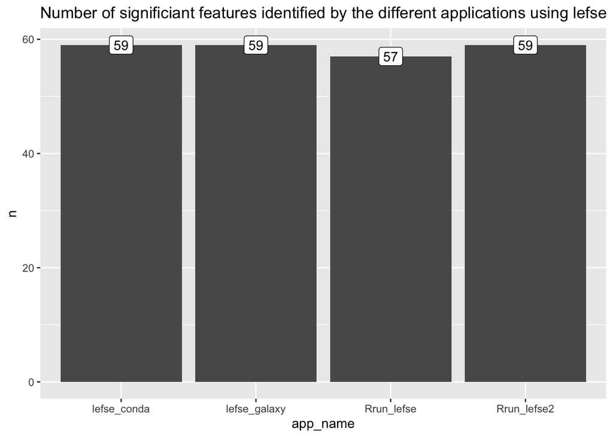

```r
plot_signif_taxa_num <- function(dat1, dat2, dat3, dat4) {

    # dat1 = amplicon_ps_genus_lefse_conda
    # dat2 = amplicon_ps_genus_lefse_galaxy
    # dat3 = amplicon_ps_genus_lefse_R
    # dat4 = amplicon_ps_genus_lefse_R2

    combined_outputs <- dplyr::bind_rows(dat1, dat2, dat3, dat4) %>%
       dplyr::mutate(LDA = coalesce(lefse_conda_LDA,
                                    lefse_galaxy_LDA,
                                    lefse_R_LDA,
                                    lefse_R2_LDA))

    pl <- combined_outputs %>%
        count(app_name) %>%
        ggplot(aes(app_name, n)) +
        geom_col() +
        geom_label(aes(label = n)) +
        ggtitle('Number of significiant features identified by the different applications using lefse')

    return(pl)
}

plot_signif_taxa_num(dat1 = amplicon_ps_genus_lefse_conda,
                     dat2 = amplicon_ps_genus_lefse_galaxy,
                     dat3 = amplicon_ps_genus_lefse_R,
                     dat4 = amplicon_ps_genus_lefse_R2)
```

- Zeybel_ps_species_lefse

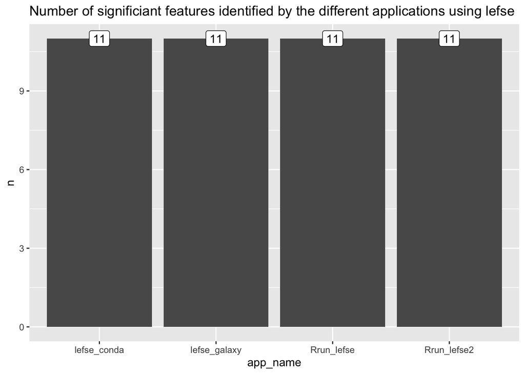

```r
plot_signif_taxa_num(dat1 = Zeybel_ps_species_lefse_conda,
                     dat2 = Zeybel_ps_species_lefse_galaxy,
                     dat3 = Zeybel_ps_species_lefse_R,
                     dat4 = Zeybel_ps_species_lefse_R2)
```

## Overlap of features reported as significant

- amplicon_ps_genus_lefse

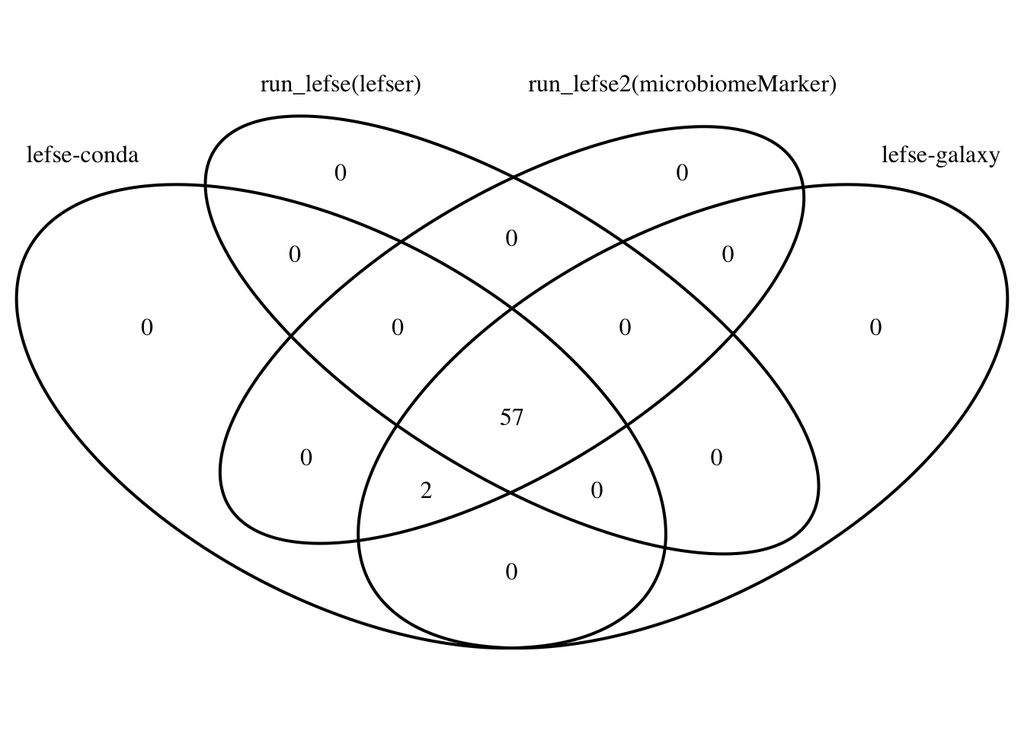

```r
plot_signif_taxa_venn <- function(dat1, dat2, dat3, dat4) {

    # dat1 = amplicon_ps_genus_lefse_conda
    # dat2 = amplicon_ps_genus_lefse_galaxy
    # dat3 = amplicon_ps_genus_lefse_R
    # dat4 = amplicon_ps_genus_lefse_R2

    set1 = dat1$TaxaID
    set2 = dat2$TaxaID
    set3 = dat3$TaxaID
    set4 = dat4$TaxaID

    grid.newpage()
    venn_object <- venn.diagram(
        x = list(set1, set2, set3, set4),
        category.names = c("lefse-conda", "lefse-galaxy",
                           "run_lefse(lefser)", "run_lefse2(microbiomeMarker)"),
        filename = NULL
    )
    grid.draw(venn_object)
}

plot_signif_taxa_venn(dat1 = amplicon_ps_genus_lefse_conda,
                      dat2 = amplicon_ps_genus_lefse_galaxy,
                      dat3 = amplicon_ps_genus_lefse_R,
                      dat4 = amplicon_ps_genus_lefse_R2)
```

- Zeybel_ps_species_lefse

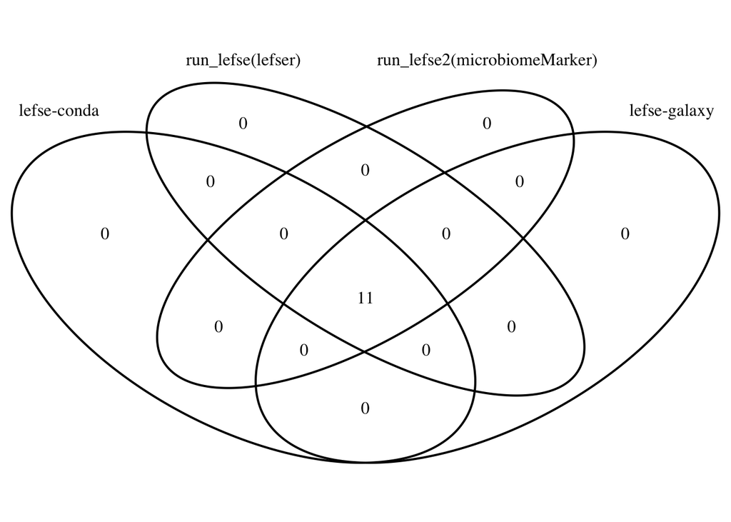

```r
plot_signif_taxa_venn(dat1 = Zeybel_ps_species_lefse_conda,
                      dat2 = Zeybel_ps_species_lefse_galaxy,
                      dat3 = Zeybel_ps_species_lefse_R,
                      dat4 = Zeybel_ps_species_lefse_R2)
```

## LDA scores’ comparison

- amplicon_ps_genus_lefse

```r
amplicon_joint_output <- purrr::reduce(
    .x = list(amplicon_ps_genus_lefse_conda, amplicon_ps_genus_lefse_galaxy,
              amplicon_ps_genus_lefse_R, amplicon_ps_genus_lefse_R2),
    .f = ~ inner_join(.x, .y, by = "TaxaID")) %>%
    dplyr::select(TaxaID, lefse_conda_LDA, lefse_galaxy_LDA,
                  lefse_R_LDA, lefse_R2_LDA)
amplicon_joint_output
```

```
## # A tibble: 57 × 5
##    TaxaID              lefse_conda_LDA lefse_galaxy_LDA lefse_R_LDA lefse_R2_LDA
##    <chr>                         <dbl>            <dbl>       <dbl>        <dbl>
##  1 g__Bacteroides                -5.47            -5.46       -5.46        -5.77
##  2 g__Lachnospiraceae…           -4.47            -4.45       -4.45        -4.77
##  3 g__Ruminococcaceae…           -4.46            -4.41       -4.39        -4.74
##  4 g__Lachnospira                -4.36            -4.38       -4.40        -4.69
##  5 g__Faecalibacterium           -4.20            -4.18       -4.21        -4.48
##  6 g__Phascolarctobac…           -4.15            -4.18       -4.18        -4.47
##  7 g__Clostridiales_u…           -4.03            -4.06       -4.04        -4.38
##  8 g__Akkermansia                -3.91            -4.04       -4.11        -4.23
##  9 g__Oscillospira               -3.87            -3.89       -3.86        -4.19
## 10 g__Rikenellaceae_u…           -3.87            -3.91       -3.86        -4.23
## # … with 47 more rows
```

- Zeybel_ps_species_lefse

```r
MGS_joint_output <- purrr::reduce(
    .x = list(Zeybel_ps_species_lefse_conda, Zeybel_ps_species_lefse_galaxy,
              Zeybel_ps_species_lefse_R, Zeybel_ps_species_lefse_R2),
    .f = ~ inner_join(.x, .y, by = "TaxaID")) %>%
    dplyr::select(TaxaID, lefse_conda_LDA, lefse_galaxy_LDA,
                  lefse_R_LDA, lefse_R2_LDA)
MGS_joint_output
```

```
## # A tibble: 11 × 5
##    TaxaID              lefse_conda_LDA lefse_galaxy_LDA lefse_R_LDA lefse_R2_LDA
##    <chr>                         <dbl>            <dbl>       <dbl>        <dbl>
##  1 s__Butyricimonas_v…            2.46             2.82        2.46         2.74
##  2 s__Bacteroides_sal…            2.47             3.16        2.63         2.78
##  3 s__Bacteroides_cla…            3.07             3.29        3.22         3.47
##  4 s__Bacteroides_the…            3.26             3.28        3.18         3.44
##  5 s__Bacteroides_cop…            3.28             3.24        3.31         3.46
##  6 s__Bacteroides_int…            3.32             3.31        3.49         3.45
##  7 s__Bacteroides_cel…            3.41             3.36        3.33         3.65
##  8 s__Bacteroides_egg…            3.52             3.59        3.41         3.82
##  9 s__Parabacteroides…            3.59             3.68        3.55         3.96
## 10 s__Barnesiella_int…            3.68             3.72        3.63         3.96
## 11 s__Prevotella_sp_C…            4.04             4.26        4.32         4.74
```

### XMAS2 LDA scores vs lefse-conda LDA scores

#### amplicon_ps_genus_lefse

- run_lefse (lefser R package) vs lefse-conda

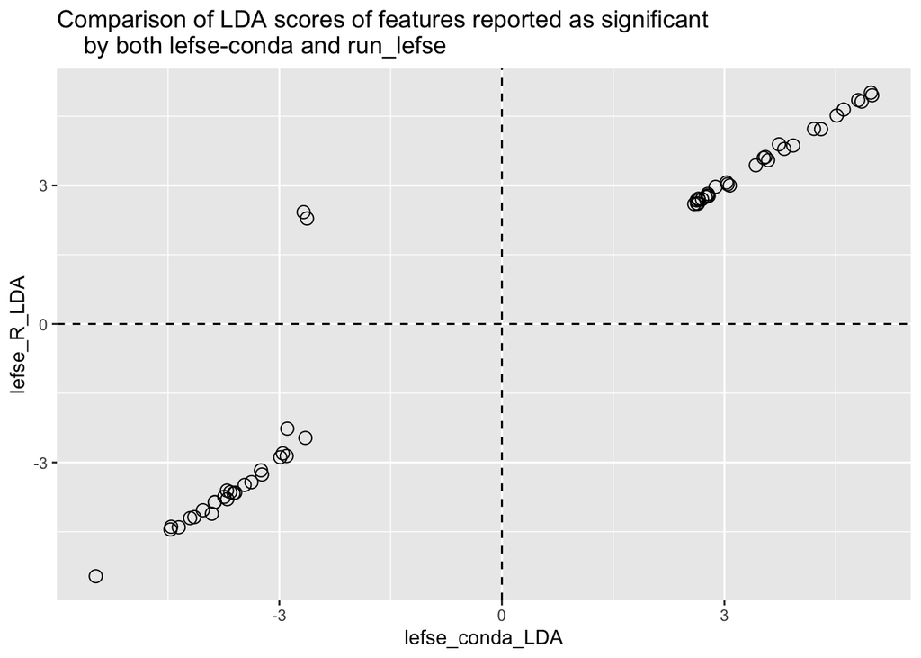

```r
amplicon_joint_output %>%
    ggplot(aes(lefse_conda_LDA, lefse_R_LDA)) +
    geom_point(size = 3, shape = 1) +
    geom_hline(yintercept = 0, linetype = "dashed") +
    geom_vline(xintercept = 0, linetype = "dashed") +
    ggtitle("Comparison of LDA scores of features reported as significant
    by both lefse-conda and run_lefse")
```

- run_lefse2 (microbiomeMarker R package) vs lefse-conda

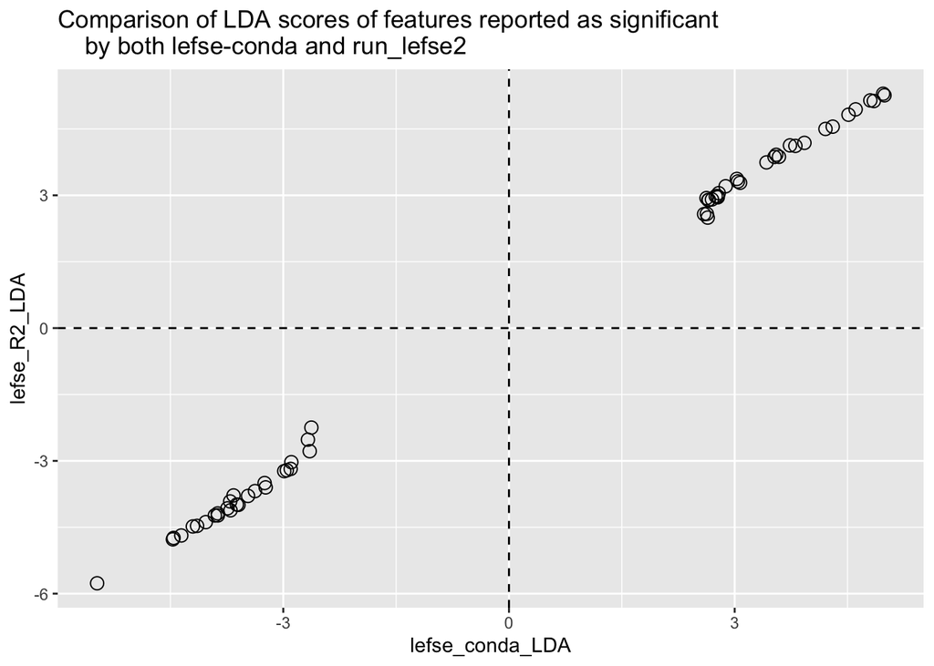

```r
amplicon_joint_output %>%
    ggplot(aes(lefse_conda_LDA, lefse_R2_LDA)) +
    geom_point(size = 3, shape = 1) +
    geom_hline(yintercept = 0, linetype = "dashed") +
    geom_vline(xintercept = 0, linetype = "dashed") +
    ggtitle("Comparison of LDA scores of features reported as significant
    by both lefse-conda and run_lefse2")
```

#### Zeybel_ps_species_lefse

- run_lefse (lefser R package) vs lefse-conda

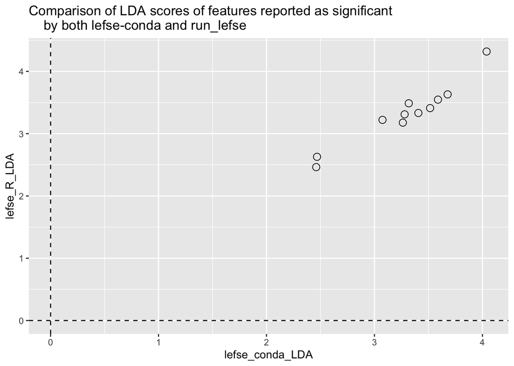

```r
MGS_joint_output %>%
    ggplot(aes(lefse_conda_LDA, lefse_R_LDA)) +
    geom_point(size = 3, shape = 1) +
    geom_hline(yintercept = 0, linetype = "dashed") +
    geom_vline(xintercept = 0, linetype = "dashed") +
    ggtitle("Comparison of LDA scores of features reported as significant
    by both lefse-conda and run_lefse")
```

- run_lefse2 (microbiomeMarker R package) vs lefse-conda

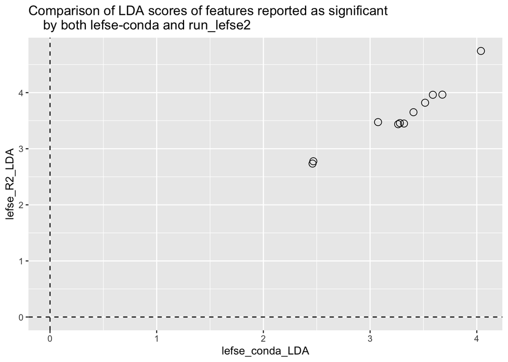

```r
MGS_joint_output %>%
    ggplot(aes(lefse_conda_LDA, lefse_R2_LDA)) +
    geom_point(size = 3, shape = 1) +
    geom_hline(yintercept = 0, linetype = "dashed") +
    geom_vline(xintercept = 0, linetype = "dashed") +
    ggtitle("Comparison of LDA scores of features reported as significant
    by both lefse-conda and run_lefse2")
```

### XMAS2 LDA scores vs lefse-galaxy LDA scores

#### amplicon_ps_genus_lefse

- run_lefse (lefser R package) vs lefse-galaxy

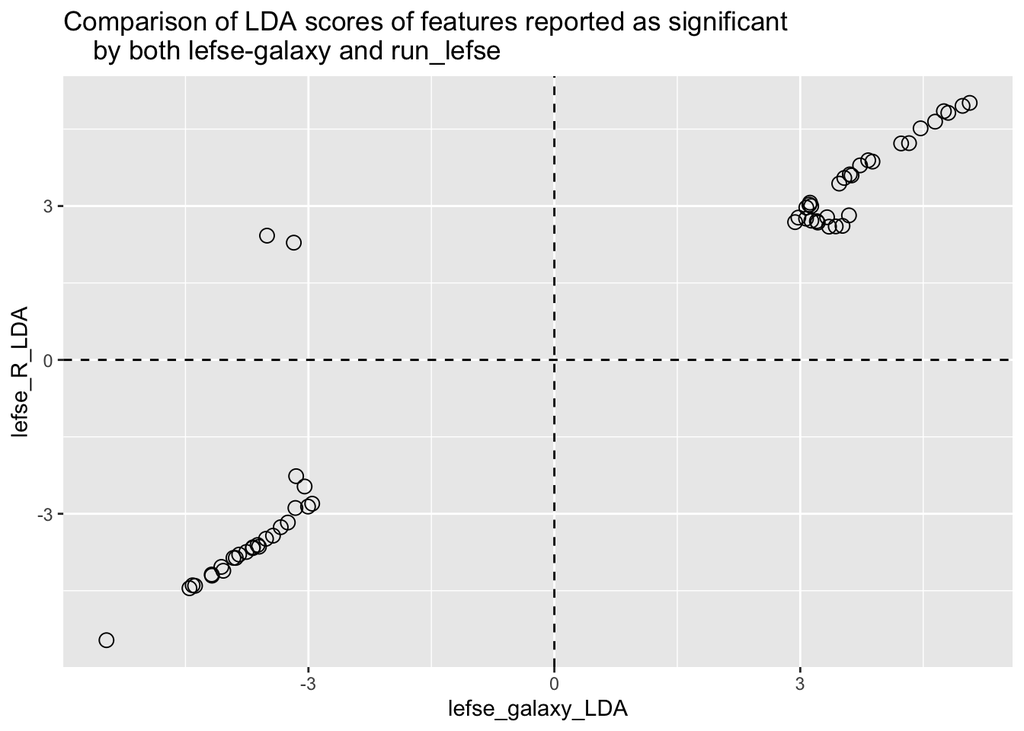

```r
amplicon_joint_output %>%
    ggplot(aes(lefse_galaxy_LDA, lefse_R_LDA)) +
    geom_point(size = 3, shape = 1) +
    geom_hline(yintercept = 0, linetype = "dashed") +
    geom_vline(xintercept = 0, linetype = "dashed") +
    ggtitle("Comparison of LDA scores of features reported as significant
    by both lefse-galaxy and run_lefse")
```

- run_lefse2 (microbiomeMarker R package) vs lefse-galaxy

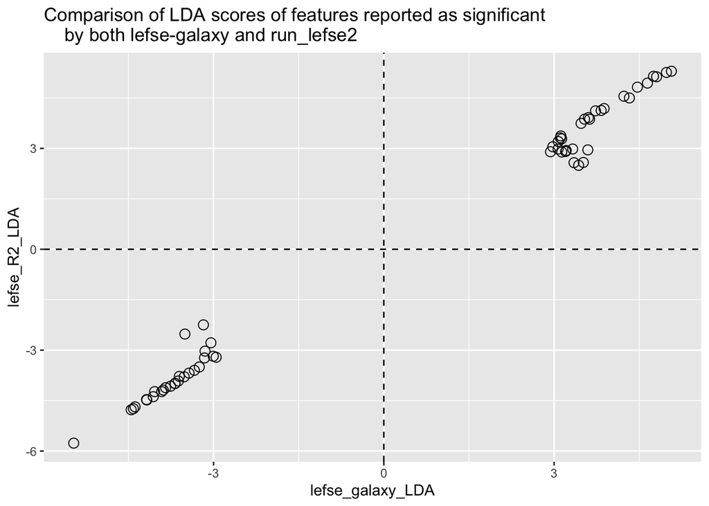

```r
amplicon_joint_output %>%
    ggplot(aes(lefse_galaxy_LDA, lefse_R2_LDA)) +
    geom_point(size = 3, shape = 1) +
    geom_hline(yintercept = 0, linetype = "dashed") +
    geom_vline(xintercept = 0, linetype = "dashed") +
    ggtitle("Comparison of LDA scores of features reported as significant
    by both lefse-galaxy and run_lefse2")
```

#### Zeybel_ps_species_lefse

- run_lefse (lefser R package) vs lefse-galaxy

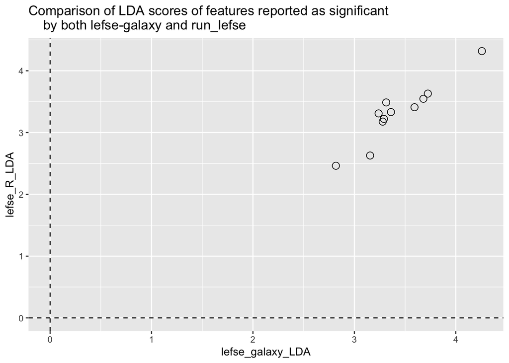

```r
MGS_joint_output %>%
    ggplot(aes(lefse_galaxy_LDA, lefse_R_LDA)) +
    geom_point(size = 3, shape = 1) +
    geom_hline(yintercept = 0, linetype = "dashed") +
    geom_vline(xintercept = 0, linetype = "dashed") +
    ggtitle("Comparison of LDA scores of features reported as significant
    by both lefse-galaxy and run_lefse")
```

- run_lefse2 (microbiomeMarker R package) vs lefse-galaxy

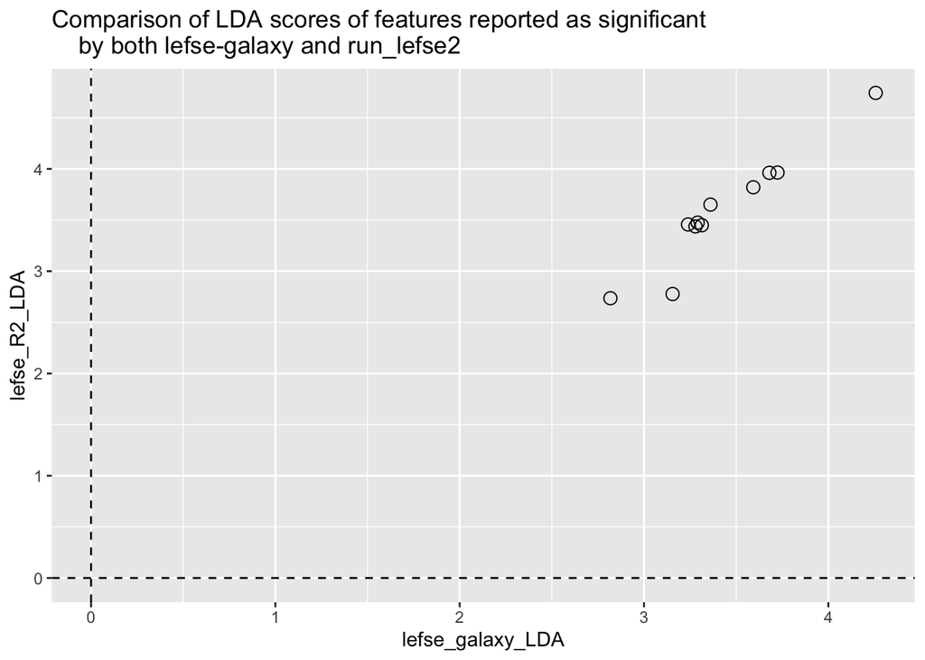

```r
MGS_joint_output %>%
    ggplot(aes(lefse_galaxy_LDA, lefse_R2_LDA)) +
    geom_point(size = 3, shape = 1) +
    geom_hline(yintercept = 0, linetype = "dashed") +
    geom_vline(xintercept = 0, linetype = "dashed") +
    ggtitle("Comparison of LDA scores of features reported as significant
    by both lefse-galaxy and run_lefse2")
```

**Results:**

### Differences bewteen XMAS2 LDA scores and lefse-conda

```r
setdiff(amplicon_ps_genus_lefse_conda$TaxaID, amplicon_ps_genus_lefse_R$TaxaID)
```

```
## [1] "g__Holdemania"                  "g__Alcaligenaceae_unclassified"
```

```r
setdiff(amplicon_ps_genus_lefse_conda$TaxaID, amplicon_ps_genus_lefse_R2$TaxaID)
```

```
## character(0)
```